# Credit Risk Scoring (Score de défaut client)

Cas métier Finance / Risque — UCI Statlog German Credit

Author

Cédric LEBE

Published

March 16, 2026

## 1. Objectif décisionnel

L’objectif est de **scorer le risque de défaut** d’un client afin de soutenir une décision de crédit. La sortie attendue est un **tableau de scores** (probabilité de défaut) et une **politique de décision** opérationnelle :

- *approve* : risque faible
- *review* : risque intermédiaire (analyse manuelle)
- *reject* : risque élevé

## 2. Données

### 2.1 Source

Le projet utilise le dataset **Statlog (German Credit Data)** (UCI).  
Le fichier brut `german.data` est encodé (modalités Axx) et converti automatiquement en CSV par le pipeline.

### 2.2 Structure des données

Le dataset **Statlog (German Credit Data)** est composé de **20 variables explicatives** (mélange de variables qualitatives encodées et numériques), ainsi que d’une variable cible.

Les variables qualitatives sont encodées sous forme de **modalités Axx**, selon la documentation officielle UCI.

#### Variables financières et contractuelles

- **Status of existing checking account** *(qualitative)*
  - A11 : < 0 DM
  - A12 : 0 ≤ … < 200 DM
  - A13 : ≥ 200 DM / salaire assigné ≥ 1 an
  - A14 : pas de compte courant
- **Duration in month** *(numérique)*  
  Durée du crédit en mois.
- **Credit history** *(qualitative)*
  - A30 : aucun crédit / tous remboursés
  - A31 : crédits à cette banque remboursés
  - A32 : crédits existants correctement remboursés
  - A33 : retards de paiement dans le passé
  - A34 : compte critique / autres crédits existants
- **Purpose** *(qualitative)*
  - A40 : voiture (neuve)
  - A41 : voiture (occasion)
  - A42 : meubles / équipement
  - A43 : radio / télévision
  - A44 : électroménager
  - A45 : réparations
  - A46 : éducation
  - A49 : business
  - A410 : autres
- **Credit amount** *(numérique)*  
  Montant du crédit (en DM).
- **Savings account / bonds** *(qualitative)*
  - A61 : < 100 DM
  - A62 : 100 ≤ … < 500 DM
  - A63 : 500 ≤ … < 1000 DM
  - A64 : ≥ 1000 DM
  - A65 : inconnu / pas d’épargne

#### Variables socio-professionnelles

- **Present employment since** *(qualitative)*
  - A71 : sans emploi
  - A72 : < 1 an
  - A73 : 1 à 4 ans
  - A74 : 4 à 7 ans
  - A75 : ≥ 7 ans
- **Installment rate** *(numérique)*  
  Taux de mensualité en pourcentage du revenu disponible.
- **Personal status and sex** *(qualitative)*
  - A91 : homme divorcé / séparé
  - A92 : femme divorcée / mariée
  - A93 : homme célibataire
  - A94 : homme marié / veuf
  - A95 : femme célibataire
- **Other debtors / guarantors** *(qualitative)*
  - A101 : aucun
  - A102 : co-emprunteur
  - A103 : garant
- **Present residence since** *(numérique)*  
  Ancienneté de résidence (années).
- **Property** *(qualitative)*
  - A121 : immobilier
  - A122 : épargne logement / assurance-vie
  - A123 : véhicule ou autre
  - A124 : aucun bien
- **Age** *(numérique)*  
  Âge du client (années).
- **Other installment plans** *(qualitative)*
  - A141 : banque
  - A142 : magasins
  - A143 : aucun
- **Housing** *(qualitative)*
  - A151 : locataire
  - A152 : propriétaire
  - A153 : logement gratuit
- **Number of existing credits** *(numérique)*  
  Nombre de crédits existants dans la banque.
- **Job** *(qualitative)*
  - A171 : sans emploi / non qualifié (non résident)
  - A172 : non qualifié (résident)
  - A173 : employé qualifié
  - A174 : cadre / indépendant / hautement qualifié
- **Number of dependents** *(numérique)*  
  Nombre de personnes à charge.
- **Telephone** *(qualitative)*
  - A191 : aucun
  - A192 : téléphone enregistré au nom du client
- **Foreign worker** *(qualitative)*
  - A201 : oui
  - A202 : non

### 2.3 Cible

La cible originale est `class` :

| `class` | Signification |
| --- | --- |
| `1` | bon crédit |
| `2` | mauvais crédit |

Elle est convertie en **default** :

| `default` | Signification |
| --- | --- |
| `1` | défaut / mauvais crédit |
| `0` | non défaut |

## 3. Reproductibilité & pipeline d’exécution

Le pipeline est orchestré par `R/run_all.R` et génère l’ensemble des artefacts utilisés dans ce rapport.

**Commandes :**

```bash
# Exécution complète du pipeline
Rscript -e "source('R/run_all.R')"

# Génération du rapport
quarto render
```

## 4. Analyse exploratoire orientée décision (EDA)

Cette EDA vise à identifier les profils à risque et à vérifier la cohérence du scoring dans une logique d’aide à la décision crédit.

### 4.1 Taux de défaut (baseline)

| default | n | p |
| --- | --- | --- |
| default | 60 | 30 |
| no_default | 140 | 70 |

### 4.2 Distribution des probabilités de défaut

Question métier : le modèle sépare-t-il correctement bons et mauvais crédits ?

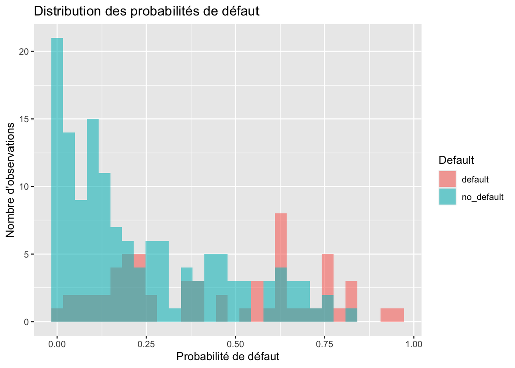

### 4.3 Politique de décision (3 niveaux)

Question métier : quelle proportion de clients est acceptée, revue ou rejetée ?

| decision | n | p |
| --- | --- | --- |
| approve | 87 | 43.5 |
| reject | 20 | 10.0 |
| review | 93 | 46.5 |

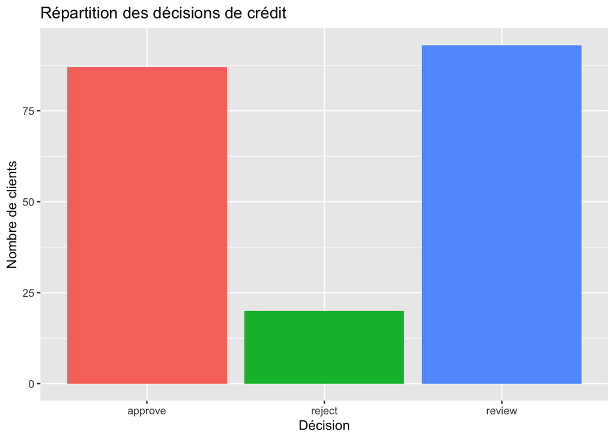

### 4.4 Cohérence du risque par décision

Question métier : les décisions sont-elles cohérentes avec le risque estimé ?

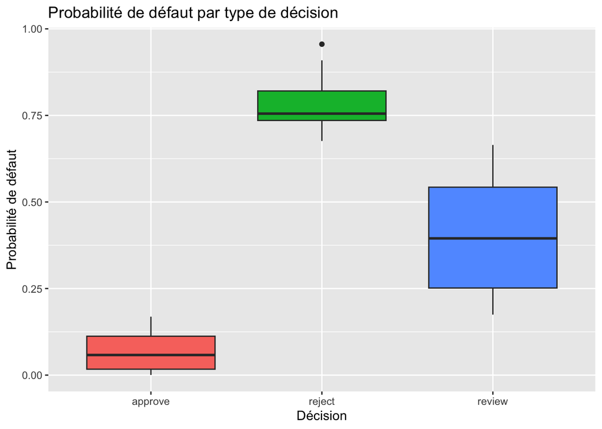

### 4.5 Top clients les plus risqués

| default | proba_default | decision |
| --- | --- | --- |
| default | 0.9557899 | reject |
| default | 0.9090702 | reject |
| default | 0.8391218 | reject |
| default | 0.8362558 | reject |
| default | 0.8264837 | reject |
| no_default | 0.8186843 | reject |
| default | 0.7894994 | reject |
| default | 0.7741864 | reject |
| default | 0.7577793 | reject |
| no_default | 0.7559192 | reject |

## 5. Modélisation

Deux modèles ont été comparés :

- Régression logistique (baseline interprétable)
- Arbre de décision (tuning)

| model | roc_auc | accuracy | f1 |
| --- | --- | --- | --- |
| logistic_glm | 0.7296429 | 0.730 | 0.500000 |
| decision_tree_tuned | 0.7064286 | 0.695 | 0.487395 |

Modèle retenu : Régression logistique (AUC supérieure et meilleure interprétabilité).

## 6. Interprétabilité du modèle (régression logistique)

Dans un contexte de **risque de crédit**, la performance prédictive seule n’est pas suffisante. Il est indispensable de **comprendre et expliquer** les facteurs qui influencent le risque de défaut, afin de justifier les décisions auprès des équipes métiers et réglementaires.

Le modèle retenu étant une **régression logistique**, celle-ci offre une bonne **interprétabilité** via l’analyse de ses coefficients.

### 6.1 Principe d’interprétation

Dans une régression logistique :

- un **coefficient positif** augmente la probabilité de défaut,
- un **coefficient négatif** réduit la probabilité de défaut,
- l’amplitude du coefficient reflète l’intensité de l’effet (toutes choses égales par ailleurs).

### 6.2 Importance des variables (coefficients)

Top 15 variables les plus influentes

| term | estimate | std.error | statistic | p.value |
| --- | --- | --- | --- | --- |
| status_checking_A14 | -0.8418374 | 0.1268431 | -6.6368382 | 3.204832e-11 |
| credit_history_A34 | -0.7838523 | 0.2371018 | -3.3059732 | 9.464714e-04 |
| purpose_A41 | -0.6934196 | 0.1436154 | -4.8283102 | 1.376965e-06 |
| savings_A65 | -0.5173206 | 0.1215760 | -4.2551208 | 2.089361e-05 |
| purpose_A43 | -0.4070620 | 0.1235877 | -3.2937086 | 9.887493e-04 |
| credit_amount | 0.3999693 | 0.1480340 | 2.7018740 | 6.894988e-03 |
| installment_rate | 0.3713794 | 0.1154559 | 3.2166353 | 1.297034e-03 |
| foreign_worker_A202 | -0.3412713 | 0.1480390 | -2.3052795 | 2.115092e-02 |
| status_checking_A13 | -0.3225468 | 0.1089509 | -2.9604793 | 3.071607e-03 |
| property_A124 | 0.3194827 | 0.1796596 | 1.7782666 | 7.536009e-02 |

[output cut: 5 more lines]

### 6.3 Visualisation des effets principaux

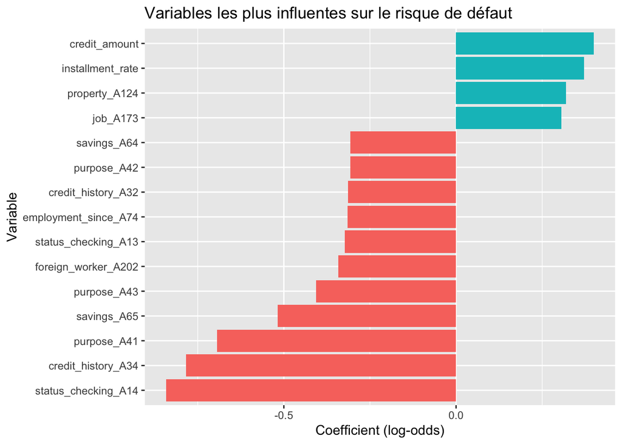

### 6.4 Lecture métier des principaux facteurs de risque

À l’inverse, certains facteurs sont associés à une réduction du risque :

- ancienneté professionnelle élevée,
- présence d’épargne significative,
- situation résidentielle stable (propriétaire).

### 6.5 Apport pour la décision crédit

L’interprétabilité du modèle permet :

- de justifier les décisions automatisées,
- d’identifier les leviers de mitigation du risque (garanties, durée, apport),
- de faciliter l’analyse manuelle des dossiers en *review*.

Elle constitue un prérequis essentiel pour une utilisation opérationnelle du scoring en environnement bancaire ou financier.

## 7. Choix du seuil & politique de décision

### 7.1 Principe risque (Recall défaut)

En risque de crédit, l’objectif est de limiter les défauts non détectés (faux négatifs). Le seuil review est calibré pour garantir Recall(default) ≥ 80% sur le set de test.

### 7.2 Compromis recall / spécificité

| threshold | recall | specificity | precision | f1 | TP | FP | TN | FN |
| --- | --- | --- | --- | --- | --- | --- | --- | --- |
| 0.01 | 1.0000000 | 0.07142857 | 0.3157895 | 0.4800000 | 60 | 130 | 10 | 0 |
| 0.02 | 0.9833333 | 0.15714286 | 0.3333333 | 0.4978903 | 59 | 118 | 22 | 1 |
| 0.04 | 0.9666667 | 0.22857143 | 0.3493976 | 0.5132743 | 58 | 108 | 32 | 2 |
| 0.03 | 0.9666667 | 0.19285714 | 0.3391813 | 0.5021645 | 58 | 113 | 27 | 2 |
| 0.05 | 0.9500000 | 0.25000000 | 0.3518519 | 0.5135135 | 57 | 105 | 35 | 3 |
| 0.06 | 0.9333333 | 0.28571429 | 0.3589744 | 0.5185185 | 56 | 100 | 40 | 4 |
| 0.07 | 0.9333333 | 0.28571429 | 0.3589744 | 0.5185185 | 56 | 100 | 40 | 4 |
| 0.09 | 0.9166667 | 0.32857143 | 0.3691275 | 0.5263158 | 55 | 94 | 46 | 5 |
| 0.08 | 0.9166667 | 0.30714286 | 0.3618421 | 0.5188679 | 55 | 97 | 43 | 5 |
| 0.10 | 0.9000000 | 0.37142857 | 0.3802817 | 0.5346535 | 54 | 88 | 52 | 6 |

[output cut: 5 more lines]

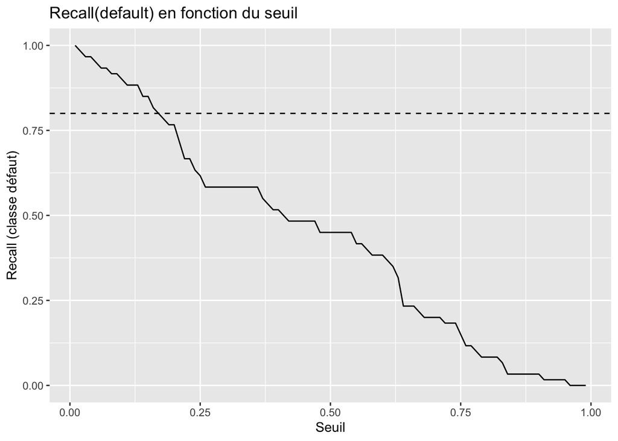

Le seuil reject est défini comme le quantile correspondant aux 10% de scores les plus élevés (top risque), afin d’implémenter une politique prudente.

## 8. Tableau de scores & recommandations

Le scoring final inclut :

- probabilité de défaut proba_default
- décision (approve / review / reject)

| default | proba_default | decision |
| --- | --- | --- |
| no_default | 0.021599866 | approve |
| no_default | 0.258260277 | review |
| default | 0.664715853 | review |
| no_default | 0.008585508 | approve |
| default | 0.789499366 | reject |
| no_default | 0.102623026 | approve |
| no_default | 0.238775918 | review |
| no_default | 0.168752849 | approve |
| no_default | 0.356098915 | review |
| no_default | 0.199533628 | review |

Recommandations d’usage :

- approve : décision automatique
- review : analyse manuelle / pièces complémentaires / garanties
- reject : rejet (ou validation manager selon politique)

## 9. Dashboard Shiny & Streamlit

Deux applications interactives, **Shiny** et **Streamlit**, sont fournies et accessibles via les liens ci-dessous :

- [Shiny](https://cedric-lebe.shinyapps.io/credit-risk-dashboard/)
- [Streamlit](https://credit-default-scoring.streamlit.app/)

Ces applications permettent de :

- visualiser la distribution des scores,
- filtrer par décision,
- consulter les utilisateurs les plus risqués.

Elles illustrent également l’**interopérabilité entre R et Python**, les visualisations Streamlit reposant sur des exports générés par le pipeline **R**.

## 10. Limites et pistes d’amélioration

Limites :

- dataset encodé (Axx) : interprétation métier partielle sans dictionnaire complet.

Améliorations :

- l’utilisation de **techniques de calibration de probabilités**,
- une **évaluation économique du scoring** (expected loss).